# Big Data Analysis

Bagging, Random Forests and Boosting

Christoph Kern

## Setup

```r
library(caret)
library(randomForest)
library(xgboost)
library(pROC)
library(ranger)
```

In this exercise, we again use the reduced version of the BACH data set.

```r
load("BACH.Rda")
```

## Data preparation

Our machine learning task is – again – to predict whether a corporation experiences a net loss in the year 2015. Therefore, we first compute a binary variable which indicates a loss with “loss” and returns “no_loss” otherwise, based on the variable `bach$net_profit_or_loss`.

```r
bach$D_loss <- ifelse(bach$net_profit_or_loss < 0, "loss", "no_loss")
bach$D_loss <- as.factor(bach$D_loss)
summary(bach$D_loss)
```

```
   loss no_loss
   1549    9698
```

Then we split the data set into a training and test part, using the year 2015 for the test set.

```r
bach_test <- bach[bach$year == "2015",]
bach_train <- bach[bach$year != "2015",]
```

## Random Forest

We may want to grow a random forest as a first classifier, using `caret`. This time, we want to account for the longitudinal data structure in the cross-validation process. For this, take a look at the function `groupKFold()` and apply it as needed here.

```r
folds <- groupKFold(bach_train$year)
lengths(folds)
```

```
Fold01 Fold02 Fold03 Fold04 Fold05 Fold06 Fold07 Fold08 Fold09 Fold10 Fold11 Fold12 Fold13 Fold14
  9968   9963   9962   9960   9945   9788   9776   9775   9769   9772   9768   9770   9759   9764
Fold15
  9835
```

The resulting object from `groupKFold()` can be passed to the `index` argument of the `trainControl()` function. Furthermore, we use cross-validation as the evaluation method for model tuning.

```r
ctrl  <- trainControl(method = "cv",
                      index = folds,
                      summaryFunction = twoClassSummary,
                      classProbs = TRUE,
                      verboseIter = TRUE)
```

Before training random forests, we specifiy try-out values for the tuning parameter(s).

```r
ncols <- ncol(model.matrix(D_loss ~ . - net_profit_or_loss - return_on_equity,
                           data = bach_train)[,-1])
grid <- expand.grid(mtry = c(floor(log(ncols)), floor(sqrt(ncols))),
                    splitrule = "gini",
                    min.node.size = 5)
```

Now we can use `train()` from `caret` in order to grow the forest. Use the binary loss variable as the outcome and `~ . - net_profit_or_loss - return_on_equity` on the right hand side of the function call.

```r
rf <- train(D_loss ~ . - net_profit_or_loss - return_on_equity,
            data = bach_train,
            method = "ranger",
            trControl = ctrl,
            tuneGrid = grid,
            importance = 'impurity',
            metric = "ROC")
```

Here we can add some code for inspecting the random forest results.

```r
rf
```

```
Random Forest

10541 samples
   14 predictors
    2 classes: 'loss', 'no_loss'

No pre-processing
Resampling: Cross-Validated (10 fold)
Summary of sample sizes: 9968, 9963, 9962, 9960, 9945, 9788, ...
Resampling results across tuning parameters:

  mtry  ROC        Sens       Spec
  4     0.9108526  0.4172992  0.9924891
  7     0.9139556  0.4801811  0.9880420

Tuning parameter 'splitrule' was held constant at a value of gini
Tuning parameter
 'min.node.size' was held constant at a value of 5
ROC was used to select the optimal model using the largest value.
The final values used for the model were mtry = 7, splitrule = gini and min.node.size = 5.
```

```r
varImp(rf)
```

```
ranger variable importance

  only 20 most important variables shown (out of 55)

                  Overall
staff_costs       100.000
fixed_assets       83.249
total_liabilities  80.523
total_equity       79.159
total_assets       77.563
current_assets     76.893
gross_value_added  73.946
turnover           71.363
countryIT          47.424
sectorR            35.960
countryPT          20.111
sectorI            15.151
size1a             13.383
sectorJ            10.738
sectorS            10.706
size2               9.991
countryDE           9.853
size1b              9.738
year2012            8.776
countryFR           8.264
```

### Boosting

We may want to use Boosting as an additional prediction method. When using `xgboost`, it is useful to specify a tuning grid first.

```r
grid <- expand.grid(max_depth = 1:3,
                    nrounds = c(250, 500),
                    eta = 0.05,
                    min_child_weight = 5,
                    subsample = 0.7,
                    gamma = 0,
                    colsample_bytree = 1)
grid
```

| max_depth | nrounds | eta | min_child_weight | subsample | gamma | colsample_bytree |
| --- | --- | --- | --- | --- | --- | --- |
| 1 | 250 | 0.05 | 5 | 0.7 | 0 | 1 |
| 2 | 250 | 0.05 | 5 | 0.7 | 0 | 1 |
| 3 | 250 | 0.05 | 5 | 0.7 | 0 | 1 |
| 1 | 500 | 0.05 | 5 | 0.7 | 0 | 1 |
| 2 | 500 | 0.05 | 5 | 0.7 | 0 | 1 |
| 3 | 500 | 0.05 | 5 | 0.7 | 0 | 1 |

Now we can pass this grid to `train()`, using `xgbTree` as the machine learning method. Many arguments can be copied from the previous call to `train()`.

```r
xgb <- train(D_loss ~ . - net_profit_or_loss - return_on_equity,
             data = bach_train,
             method = "xgbTree",
             trControl = ctrl,
             tuneGrid = grid,
             metric = "ROC")
```

Again, take a look at the results from the tuning process, e.g. by printing and/or plotting the corresponding object.

```r
xgb
```

[output not shown]

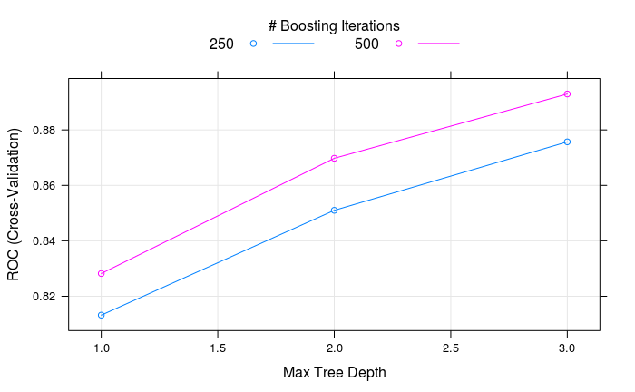

```r
plot(xgb)
```

```r
varImp(xgb)
```

```
xgbTree variable importance

  only 20 most important variables shown (out of 55)

                  Overall
staff_costs       100.000
total_equity       76.635
fixed_assets       63.689
gross_value_added  61.099
countryIT          58.643
current_assets     48.479
total_assets       47.697
sectorR            33.866
turnover           33.743
countryPT          32.492
sectorE            19.074
countryFR          11.199
year2007           10.859
size1a             10.780
countrySK          10.730
sectorI             9.936
countryDE           9.527
sectorS             8.835
size2               8.614
year2005            8.002
```

## Prediction

Next, we can use `predict()` in order to predict class membership and predicted probabilities in the test set based on the results from both classifiers.

```r
rf_class <- predict(rf, newdata = bach_test)
xgb_class <- predict(xgb, newdata = bach_test)
rf_prob <- predict(rf, newdata = bach_test, type = "prob")
xgb_prob <- predict(xgb, newdata = bach_test, type = "prob")
```

Given predicted class membership, we can use `confusionMatrix()` for evaluating prediction performance.

```r
confusionMatrix(rf_class, bach_test$D_loss)
```

```
Confusion Matrix and Statistics

          Reference
Prediction loss no_loss
   loss      36      23
   no_loss   30     617

               Accuracy : 0.9249
                 95% CI : (0.903, 0.9433)
    No Information Rate : 0.9065
    P-Value [Acc > NIR] : 0.04971

                  Kappa : 0.535
 Mcnemar's Test P-Value : 0.40985

            Sensitivity : 0.54545
            Specificity : 0.96406
         Pos Pred Value : 0.61017
         Neg Pred Value : 0.95363
             Prevalence : 0.09348
         Detection Rate : 0.05099
   Detection Prevalence : 0.08357
      Balanced Accuracy : 0.75476

       'Positive' Class : loss
```

```r
confusionMatrix(xgb_class, bach_test$D_loss)
```

```
Confusion Matrix and Statistics

          Reference
Prediction loss no_loss
   loss      33      26
   no_loss   33     614

               Accuracy : 0.9164
                 95% CI : (0.8935, 0.9358)
    No Information Rate : 0.9065
    P-Value [Acc > NIR] : 0.2018

                  Kappa : 0.4823
 Mcnemar's Test P-Value : 0.4347

            Sensitivity : 0.50000
            Specificity : 0.95937
         Pos Pred Value : 0.55932
         Neg Pred Value : 0.94900
             Prevalence : 0.09348
         Detection Rate : 0.04674
   Detection Prevalence : 0.08357
      Balanced Accuracy : 0.72969

       'Positive' Class : loss
```

Finally, we add ROC curves for comparing the random forest and XGBoost results.

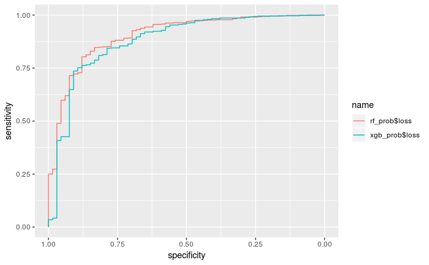

```r
roc.list <- roc(bach_test$D_loss ~ rf_prob$loss + xgb_prob$loss)
ggroc(roc.list)
```